# Risk Factor Analysis

## Outcome Variable

**Outcome Variable:** ever_co

## Predictor Variables

**Intervention Variable:** birthlen

**Adjustment Set:**

- arm
- sex
- W_mage
- meducyrs
- feducyrs
- vagbrth
- single
- brthmon
- W_parity
- delta_W_mage
- delta_meducyrs
- delta_feducyrs
- delta_vagbrth
- delta_single
- delta_brthmon
- delta_W_parity

## Stratifying Variables

The analysis was stratified on these variable(s):

- agecat
- studyid
- country

## Data Summary

| agecat | studyid | country | birthlen | ever_co | n_cell | n |
| --- | --- | --- | --- | --- | --- | --- |
| 0-24 months | ki0047075b-MAL-ED | BANGLADESH | >=50 cm | 0 | 34 | 229 |
| 0-24 months | ki0047075b-MAL-ED | BANGLADESH | >=50 cm | 1 | 5 | 229 |
| 0-24 months | ki0047075b-MAL-ED | BANGLADESH | <48 cm | 0 | 88 | 229 |
| 0-24 months | ki0047075b-MAL-ED | BANGLADESH | <48 cm | 1 | 23 | 229 |
| 0-24 months | ki0047075b-MAL-ED | BANGLADESH | [48-50) cm | 0 | 70 | 229 |
| 0-24 months | ki0047075b-MAL-ED | BANGLADESH | [48-50) cm | 1 | 9 | 229 |
| 0-24 months | ki0047075b-MAL-ED | BRAZIL | >=50 cm | 0 | 30 | 65 |
| 0-24 months | ki0047075b-MAL-ED | BRAZIL | >=50 cm | 1 | 0 | 65 |
| 0-24 months | ki0047075b-MAL-ED | BRAZIL | <48 cm | 0 | 16 | 65 |
| 0-24 months | ki0047075b-MAL-ED | BRAZIL | <48 cm | 1 | 1 | 65 |
| 0-24 months | ki0047075b-MAL-ED | BRAZIL | [48-50) cm | 0 | 18 | 65 |
| 0-24 months | ki0047075b-MAL-ED | BRAZIL | [48-50) cm | 1 | 0 | 65 |
| 0-24 months | ki0047075b-MAL-ED | INDIA | >=50 cm | 0 | 9 | 47 |
| 0-24 months | ki0047075b-MAL-ED | INDIA | >=50 cm | 1 | 0 | 47 |
| 0-24 months | ki0047075b-MAL-ED | INDIA | <48 cm | 0 | 12 | 47 |
| 0-24 months | ki0047075b-MAL-ED | INDIA | <48 cm | 1 | 8 | 47 |
| 0-24 months | ki0047075b-MAL-ED | INDIA | [48-50) cm | 0 | 13 | 47 |
| 0-24 months | ki0047075b-MAL-ED | INDIA | [48-50) cm | 1 | 5 | 47 |
| 0-24 months | ki0047075b-MAL-ED | NEPAL | >=50 cm | 0 | 8 | 27 |
| 0-24 months | ki0047075b-MAL-ED | NEPAL | >=50 cm | 1 | 0 | 27 |
| 0-24 months | ki0047075b-MAL-ED | NEPAL | <48 cm | 0 | 9 | 27 |
| 0-24 months | ki0047075b-MAL-ED | NEPAL | <48 cm | 1 | 3 | 27 |
| 0-24 months | ki0047075b-MAL-ED | NEPAL | [48-50) cm | 0 | 6 | 27 |
| 0-24 months | ki0047075b-MAL-ED | NEPAL | [48-50) cm | 1 | 1 | 27 |
| 0-24 months | ki0047075b-MAL-ED | PERU | >=50 cm | 0 | 52 | 233 |
| 0-24 months | ki0047075b-MAL-ED | PERU | >=50 cm | 1 | 0 | 233 |
| 0-24 months | ki0047075b-MAL-ED | PERU | <48 cm | 0 | 80 | 233 |
| 0-24 months | ki0047075b-MAL-ED | PERU | <48 cm | 1 | 8 | 233 |
| 0-24 months | ki0047075b-MAL-ED | PERU | [48-50) cm | 0 | 91 | 233 |
| 0-24 months | ki0047075b-MAL-ED | PERU | [48-50) cm | 1 | 2 | 233 |

[output cut: 438 more lines]

The following strata were considered:

- agecat: 0-24 months, studyid: ki0047075b-MAL-ED, country: BANGLADESH
- agecat: 0-24 months, studyid: ki0047075b-MAL-ED, country: BRAZIL
- agecat: 0-24 months, studyid: ki0047075b-MAL-ED, country: INDIA
- agecat: 0-24 months, studyid: ki0047075b-MAL-ED, country: NEPAL
- agecat: 0-24 months, studyid: ki0047075b-MAL-ED, country: PERU
- agecat: 0-24 months, studyid: ki0047075b-MAL-ED, country: SOUTH AFRICA
- agecat: 0-24 months, studyid: ki0047075b-MAL-ED, country: TANZANIA, UNITED REPUBLIC OF
- agecat: 0-24 months, studyid: ki1000108-CMC-V-BCS-2002, country: INDIA
- agecat: 0-24 months, studyid: ki1000108-IRC, country: INDIA
- agecat: 0-24 months, studyid: ki1000109-EE, country: PAKISTAN
- agecat: 0-24 months, studyid: ki1000109-ResPak, country: PAKISTAN
- agecat: 0-24 months, studyid: ki1000304b-SAS-CompFeed, country: INDIA
- agecat: 0-24 months, studyid: ki1017093-NIH-Birth, country: BANGLADESH
- agecat: 0-24 months, studyid: ki1017093b-PROVIDE, country: BANGLADESH
- agecat: 0-24 months, studyid: ki1017093c-NIH-Crypto, country: BANGLADESH
- agecat: 0-24 months, studyid: ki1101329-Keneba, country: GAMBIA
- agecat: 0-24 months, studyid: ki1113344-GMS-Nepal, country: NEPAL
- agecat: 0-24 months, studyid: ki1114097-CMIN, country: BANGLADESH
- agecat: 0-24 months, studyid: ki1114097-CONTENT, country: PERU
- agecat: 0-24 months, studyid: ki1119695-PROBIT, country: BELARUS
- agecat: 0-24 months, studyid: ki1126311-ZVITAMBO, country: ZIMBABWE
- agecat: 0-24 months, studyid: ki1135781-COHORTS, country: GUATEMALA
- agecat: 0-24 months, studyid: ki1135781-COHORTS, country: INDIA
- agecat: 0-24 months, studyid: ki1135781-COHORTS, country: PHILIPPINES
- agecat: 0-24 months, studyid: kiGH5241-JiVitA-3, country: BANGLADESH
- agecat: 0-24 months, studyid: kiGH5241-JiVitA-4, country: BANGLADESH
- agecat: 0-6 months, studyid: ki0047075b-MAL-ED, country: BANGLADESH
- agecat: 0-6 months, studyid: ki0047075b-MAL-ED, country: BRAZIL
- agecat: 0-6 months, studyid: ki0047075b-MAL-ED, country: INDIA
- agecat: 0-6 months, studyid: ki0047075b-MAL-ED, country: NEPAL
- agecat: 0-6 months, studyid: ki0047075b-MAL-ED, country: PERU
- agecat: 0-6 months, studyid: ki0047075b-MAL-ED, country: SOUTH AFRICA
- agecat: 0-6 months, studyid: ki0047075b-MAL-ED, country: TANZANIA, UNITED REPUBLIC OF
- agecat: 0-6 months, studyid: ki1000108-CMC-V-BCS-2002, country: INDIA
- agecat: 0-6 months, studyid: ki1000108-IRC, country: INDIA
- agecat: 0-6 months, studyid: ki1000109-EE, country: PAKISTAN
- agecat: 0-6 months, studyid: ki1000109-ResPak, country: PAKISTAN
- agecat: 0-6 months, studyid: ki1000304b-SAS-CompFeed, country: INDIA
- agecat: 0-6 months, studyid: ki1017093-NIH-Birth, country: BANGLADESH
- agecat: 0-6 months, studyid: ki1017093b-PROVIDE, country: BANGLADESH
- agecat: 0-6 months, studyid: ki1017093c-NIH-Crypto, country: BANGLADESH
- agecat: 0-6 months, studyid: ki1101329-Keneba, country: GAMBIA
- agecat: 0-6 months, studyid: ki1113344-GMS-Nepal, country: NEPAL
- agecat: 0-6 months, studyid: ki1114097-CMIN, country: BANGLADESH
- agecat: 0-6 months, studyid: ki1114097-CONTENT, country: PERU
- agecat: 0-6 months, studyid: ki1119695-PROBIT, country: BELARUS
- agecat: 0-6 months, studyid: ki1126311-ZVITAMBO, country: ZIMBABWE
- agecat: 0-6 months, studyid: ki1135781-COHORTS, country: GUATEMALA
- agecat: 0-6 months, studyid: ki1135781-COHORTS, country: INDIA
- agecat: 0-6 months, studyid: ki1135781-COHORTS, country: PHILIPPINES
- agecat: 0-6 months, studyid: kiGH5241-JiVitA-3, country: BANGLADESH
- agecat: 0-6 months, studyid: kiGH5241-JiVitA-4, country: BANGLADESH
- agecat: 6-24 months, studyid: ki0047075b-MAL-ED, country: BANGLADESH
- agecat: 6-24 months, studyid: ki0047075b-MAL-ED, country: BRAZIL
- agecat: 6-24 months, studyid: ki0047075b-MAL-ED, country: INDIA
- agecat: 6-24 months, studyid: ki0047075b-MAL-ED, country: NEPAL
- agecat: 6-24 months, studyid: ki0047075b-MAL-ED, country: PERU
- agecat: 6-24 months, studyid: ki0047075b-MAL-ED, country: SOUTH AFRICA
- agecat: 6-24 months, studyid: ki0047075b-MAL-ED, country: TANZANIA, UNITED REPUBLIC OF
- agecat: 6-24 months, studyid: ki1000108-CMC-V-BCS-2002, country: INDIA
- agecat: 6-24 months, studyid: ki1000108-IRC, country: INDIA
- agecat: 6-24 months, studyid: ki1000109-EE, country: PAKISTAN
- agecat: 6-24 months, studyid: ki1000109-ResPak, country: PAKISTAN
- agecat: 6-24 months, studyid: ki1000304b-SAS-CompFeed, country: INDIA
- agecat: 6-24 months, studyid: ki1017093-NIH-Birth, country: BANGLADESH
- agecat: 6-24 months, studyid: ki1017093b-PROVIDE, country: BANGLADESH
- agecat: 6-24 months, studyid: ki1017093c-NIH-Crypto, country: BANGLADESH
- agecat: 6-24 months, studyid: ki1101329-Keneba, country: GAMBIA
- agecat: 6-24 months, studyid: ki1113344-GMS-Nepal, country: NEPAL
- agecat: 6-24 months, studyid: ki1114097-CMIN, country: BANGLADESH
- agecat: 6-24 months, studyid: ki1114097-CONTENT, country: PERU
- agecat: 6-24 months, studyid: ki1119695-PROBIT, country: BELARUS
- agecat: 6-24 months, studyid: ki1126311-ZVITAMBO, country: ZIMBABWE
- agecat: 6-24 months, studyid: ki1135781-COHORTS, country: GUATEMALA
- agecat: 6-24 months, studyid: ki1135781-COHORTS, country: INDIA
- agecat: 6-24 months, studyid: ki1135781-COHORTS, country: PHILIPPINES
- agecat: 6-24 months, studyid: kiGH5241-JiVitA-3, country: BANGLADESH
- agecat: 6-24 months, studyid: kiGH5241-JiVitA-4, country: BANGLADESH

### Dropped Strata

Some strata were dropped due to rare outcomes:

- agecat: 0-24 months, studyid: ki0047075b-MAL-ED, country: BRAZIL
- agecat: 0-24 months, studyid: ki0047075b-MAL-ED, country: INDIA
- agecat: 0-24 months, studyid: ki0047075b-MAL-ED, country: NEPAL
- agecat: 0-24 months, studyid: ki0047075b-MAL-ED, country: PERU
- agecat: 0-24 months, studyid: ki0047075b-MAL-ED, country: SOUTH AFRICA
- agecat: 0-24 months, studyid: ki0047075b-MAL-ED, country: TANZANIA, UNITED REPUBLIC OF
- agecat: 0-24 months, studyid: ki1000108-CMC-V-BCS-2002, country: INDIA
- agecat: 0-24 months, studyid: ki1000109-ResPak, country: PAKISTAN
- agecat: 0-24 months, studyid: ki1017093c-NIH-Crypto, country: BANGLADESH
- agecat: 0-24 months, studyid: ki1114097-CMIN, country: BANGLADESH
- agecat: 0-24 months, studyid: ki1114097-CONTENT, country: PERU
- agecat: 0-24 months, studyid: ki1119695-PROBIT, country: BELARUS
- agecat: 0-6 months, studyid: ki0047075b-MAL-ED, country: BANGLADESH
- agecat: 0-6 months, studyid: ki0047075b-MAL-ED, country: BRAZIL
- agecat: 0-6 months, studyid: ki0047075b-MAL-ED, country: INDIA
- agecat: 0-6 months, studyid: ki0047075b-MAL-ED, country: NEPAL
- agecat: 0-6 months, studyid: ki0047075b-MAL-ED, country: PERU
- agecat: 0-6 months, studyid: ki0047075b-MAL-ED, country: SOUTH AFRICA
- agecat: 0-6 months, studyid: ki0047075b-MAL-ED, country: TANZANIA, UNITED REPUBLIC OF
- agecat: 0-6 months, studyid: ki1000108-CMC-V-BCS-2002, country: INDIA
- agecat: 0-6 months, studyid: ki1000108-IRC, country: INDIA
- agecat: 0-6 months, studyid: ki1000109-EE, country: PAKISTAN
- agecat: 0-6 months, studyid: ki1000109-ResPak, country: PAKISTAN
- agecat: 0-6 months, studyid: ki1000304b-SAS-CompFeed, country: INDIA
- agecat: 0-6 months, studyid: ki1017093-NIH-Birth, country: BANGLADESH
- agecat: 0-6 months, studyid: ki1017093b-PROVIDE, country: BANGLADESH
- agecat: 0-6 months, studyid: ki1017093c-NIH-Crypto, country: BANGLADESH
- agecat: 0-6 months, studyid: ki1113344-GMS-Nepal, country: NEPAL
- agecat: 0-6 months, studyid: ki1114097-CMIN, country: BANGLADESH
- agecat: 0-6 months, studyid: ki1114097-CONTENT, country: PERU
- agecat: 0-6 months, studyid: ki1119695-PROBIT, country: BELARUS
- agecat: 0-6 months, studyid: ki1135781-COHORTS, country: INDIA
- agecat: 0-6 months, studyid: kiGH5241-JiVitA-3, country: BANGLADESH
- agecat: 6-24 months, studyid: ki0047075b-MAL-ED, country: BRAZIL
- agecat: 6-24 months, studyid: ki0047075b-MAL-ED, country: INDIA
- agecat: 6-24 months, studyid: ki0047075b-MAL-ED, country: NEPAL
- agecat: 6-24 months, studyid: ki0047075b-MAL-ED, country: PERU
- agecat: 6-24 months, studyid: ki0047075b-MAL-ED, country: SOUTH AFRICA
- agecat: 6-24 months, studyid: ki0047075b-MAL-ED, country: TANZANIA, UNITED REPUBLIC OF
- agecat: 6-24 months, studyid: ki1000108-CMC-V-BCS-2002, country: INDIA
- agecat: 6-24 months, studyid: ki1000109-ResPak, country: PAKISTAN
- agecat: 6-24 months, studyid: ki1017093b-PROVIDE, country: BANGLADESH
- agecat: 6-24 months, studyid: ki1017093c-NIH-Crypto, country: BANGLADESH
- agecat: 6-24 months, studyid: ki1114097-CMIN, country: BANGLADESH
- agecat: 6-24 months, studyid: ki1114097-CONTENT, country: PERU
- agecat: 6-24 months, studyid: ki1119695-PROBIT, country: BELARUS

## Methods Detail

We’re interested in the causal parameters $E[Y_a]$ for all values of $a \in \mathcal{A}$. These parameters represent the mean outcome if, possibly contrary to fact, we intervened to set all units to have $A=a$. Under the randomization and positivity assumptions, these are identified by the statistical parameters $\psi_a=E_W[E_{Y|A,W}(Y|A=a,W)]$. In addition, we’re interested in the mean of $Y$, $E[Y]$ under no intervention (the observed mean). We will estimate these parameters by using SuperLearner to fit the relevant likelihood factors – $E_{Y|A,W}(Y|A=a,W)$ and $p(A=a|W)$, and then updating our likelihood fit using a joint TMLE.

For unadjusted analyses ($W=\{\}$), initial likelihoods were estimated using Lrnr_glm to estimate the simple $E(Y|A)$ and Lrnr_mean to estimate $p(A)$. For adjusted analyses, a small library containing Lrnr_glmnet, Lrnr_xgboost, and Lrnr_mean was used.

Having estimated these parameters, we will then use the delta method to estimate relative risks and attributable risks relative to a prespecified baseline level of $A$.

# Results Detail

## Results Plots

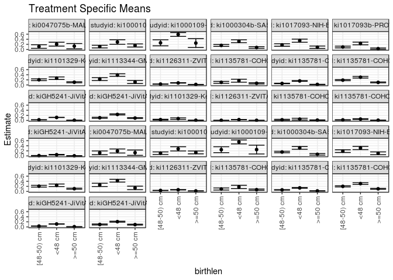

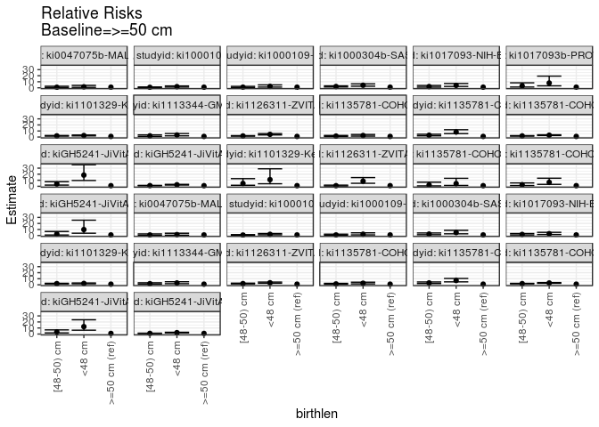

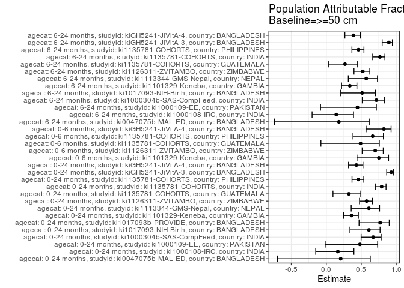

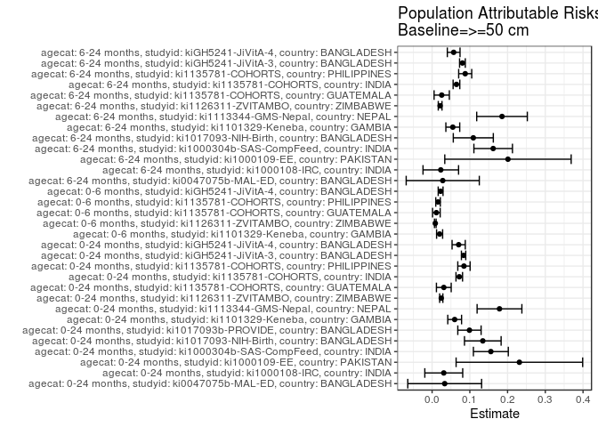

## Results Table

### Parameter: TSM

| agecat | studyid | country | intervention_level | baseline_level | estimate | ci_lower | ci_upper |
| --- | --- | --- | --- | --- | --- | --- | --- |
| 0-24 months | ki0047075b-MAL-ED | BANGLADESH | >=50 cm | NA | 0.1282051 | 0.0230511 | 0.2333592 |
| 0-24 months | ki0047075b-MAL-ED | BANGLADESH | <48 cm | NA | 0.2072072 | 0.1316425 | 0.2827719 |
| 0-24 months | ki0047075b-MAL-ED | BANGLADESH | [48-50) cm | NA | 0.1139241 | 0.0437094 | 0.1841388 |
| 0-24 months | ki1000108-IRC | INDIA | >=50 cm | NA | 0.1557910 | 0.0948726 | 0.2167093 |
| 0-24 months | ki1000108-IRC | INDIA | <48 cm | NA | 0.2909855 | 0.2026907 | 0.3792802 |
| 0-24 months | ki1000108-IRC | INDIA | [48-50) cm | NA | 0.1118922 | 0.0594311 | 0.1643532 |
| 0-24 months | ki1000109-EE | PAKISTAN | >=50 cm | NA | 0.2500000 | 0.0764015 | 0.4235985 |
| 0-24 months | ki1000109-EE | PAKISTAN | <48 cm | NA | 0.5889571 | 0.5132663 | 0.6646478 |
| 0-24 months | ki1000109-EE | PAKISTAN | [48-50) cm | NA | 0.2592593 | 0.1421330 | 0.3763855 |
| 0-24 months | ki1000304b-SAS-CompFeed | INDIA | >=50 cm | NA | 0.0762973 | 0.0438559 | 0.1087387 |
| 0-24 months | ki1000304b-SAS-CompFeed | INDIA | <48 cm | NA | 0.3203675 | 0.2639052 | 0.3768298 |
| 0-24 months | ki1000304b-SAS-CompFeed | INDIA | [48-50) cm | NA | 0.1585770 | 0.1223309 | 0.1948231 |
| 0-24 months | ki1017093-NIH-Birth | BANGLADESH | >=50 cm | NA | 0.0862099 | 0.0383038 | 0.1341159 |
| 0-24 months | ki1017093-NIH-Birth | BANGLADESH | <48 cm | NA | 0.3431972 | 0.2822625 | 0.4041319 |
| 0-24 months | ki1017093-NIH-Birth | BANGLADESH | [48-50) cm | NA | 0.1749832 | 0.1255384 | 0.2244279 |
| 0-24 months | ki1017093b-PROVIDE | BANGLADESH | >=50 cm | NA | 0.0295858 | 0.0040214 | 0.0551502 |
| 0-24 months | ki1017093b-PROVIDE | BANGLADESH | <48 cm | NA | 0.2338710 | 0.1811514 | 0.2865905 |
| 0-24 months | ki1017093b-PROVIDE | BANGLADESH | [48-50) cm | NA | 0.0954064 | 0.0611548 | 0.1296580 |
| 0-24 months | ki1101329-Keneba | GAMBIA | >=50 cm | NA | 0.1057938 | 0.0839430 | 0.1276446 |
| 0-24 months | ki1101329-Keneba | GAMBIA | <48 cm | NA | 0.2641002 | 0.2138272 | 0.3143732 |
| 0-24 months | ki1101329-Keneba | GAMBIA | [48-50) cm | NA | 0.2027844 | 0.1672731 | 0.2382958 |
| 0-24 months | ki1113344-GMS-Nepal | NEPAL | >=50 cm | NA | 0.1148343 | 0.0551544 | 0.1745142 |
| 0-24 months | ki1113344-GMS-Nepal | NEPAL | <48 cm | NA | 0.3883600 | 0.3382195 | 0.4385006 |
| 0-24 months | ki1113344-GMS-Nepal | NEPAL | [48-50) cm | NA | 0.2288585 | 0.1713812 | 0.2863358 |
| 0-24 months | ki1126311-ZVITAMBO | ZIMBABWE | >=50 cm | NA | 0.0178253 | 0.0137301 | 0.0219206 |
| 0-24 months | ki1126311-ZVITAMBO | ZIMBABWE | <48 cm | NA | 0.0787876 | 0.0707319 | 0.0868432 |
| 0-24 months | ki1126311-ZVITAMBO | ZIMBABWE | [48-50) cm | NA | 0.0324555 | 0.0276639 | 0.0372471 |
| 0-24 months | ki1135781-COHORTS | GUATEMALA | >=50 cm | NA | 0.0650166 | 0.0412430 | 0.0887901 |
| 0-24 months | ki1135781-COHORTS | GUATEMALA | <48 cm | NA | 0.1665786 | 0.1081560 | 0.2250012 |
| 0-24 months | ki1135781-COHORTS | GUATEMALA | [48-50) cm | NA | 0.1015198 | 0.0638241 | 0.1392155 |

[output cut: 66 more lines]

### Parameter: E(Y)

| agecat | studyid | country | intervention_level | baseline_level | estimate | ci_lower | ci_upper |
| --- | --- | --- | --- | --- | --- | --- | --- |
| 0-24 months | ki0047075b-MAL-ED | BANGLADESH | NA | NA | 0.1615721 | 0.1137975 | 0.2093466 |
| 0-24 months | ki1000108-IRC | INDIA | NA | NA | 0.1867008 | 0.1480272 | 0.2253743 |
| 0-24 months | ki1000109-EE | PAKISTAN | NA | NA | 0.4813278 | 0.4181144 | 0.5445412 |
| 0-24 months | ki1000304b-SAS-CompFeed | INDIA | NA | NA | 0.2320000 | 0.1911686 | 0.2728314 |
| 0-24 months | ki1017093-NIH-Birth | BANGLADESH | NA | NA | 0.2205638 | 0.1874426 | 0.2536851 |
| 0-24 months | ki1017093b-PROVIDE | BANGLADESH | NA | NA | 0.1285714 | 0.1037574 | 0.1533855 |
| 0-24 months | ki1101329-Keneba | GAMBIA | NA | NA | 0.1655928 | 0.1470936 | 0.1840919 |
| 0-24 months | ki1113344-GMS-Nepal | NEPAL | NA | NA | 0.2934307 | 0.2593074 | 0.3275539 |
| 0-24 months | ki1126311-ZVITAMBO | ZIMBABWE | NA | NA | 0.0420862 | 0.0387367 | 0.0454357 |
| 0-24 months | ki1135781-COHORTS | GUATEMALA | NA | NA | 0.0960384 | 0.0760175 | 0.1160593 |
| 0-24 months | ki1135781-COHORTS | INDIA | NA | NA | 0.0909777 | 0.0840539 | 0.0979015 |
| 0-24 months | ki1135781-COHORTS | PHILIPPINES | NA | NA | 0.1840632 | 0.1702782 | 0.1978483 |
| 0-24 months | kiGH5241-JiVitA-3 | BANGLADESH | NA | NA | 0.0897702 | 0.0855711 | 0.0939692 |
| 0-24 months | kiGH5241-JiVitA-4 | BANGLADESH | NA | NA | 0.1635066 | 0.1508784 | 0.1761348 |
| 0-6 months | ki1101329-Keneba | GAMBIA | NA | NA | 0.0264346 | 0.0184482 | 0.0344210 |
| 0-6 months | ki1126311-ZVITAMBO | ZIMBABWE | NA | NA | 0.0120947 | 0.0102659 | 0.0139235 |
| 0-6 months | ki1135781-COHORTS | GUATEMALA | NA | NA | 0.0230583 | 0.0128042 | 0.0333123 |
| 0-6 months | ki1135781-COHORTS | PHILIPPINES | NA | NA | 0.0237154 | 0.0183020 | 0.0291288 |
| 0-6 months | kiGH5241-JiVitA-4 | BANGLADESH | NA | NA | 0.0274281 | 0.0217023 | 0.0331538 |
| 6-24 months | ki0047075b-MAL-ED | BANGLADESH | NA | NA | 0.1563981 | 0.1072708 | 0.2055254 |
| 6-24 months | ki1000108-IRC | INDIA | NA | NA | 0.1611253 | 0.1246376 | 0.1976130 |
| 6-24 months | ki1000109-EE | PAKISTAN | NA | NA | 0.4510638 | 0.3873080 | 0.5148197 |
| 6-24 months | ki1000304b-SAS-CompFeed | INDIA | NA | NA | 0.2260174 | 0.1899444 | 0.2620905 |
| 6-24 months | ki1017093-NIH-Birth | BANGLADESH | NA | NA | 0.2126437 | 0.1775086 | 0.2477788 |
| 6-24 months | ki1101329-Keneba | GAMBIA | NA | NA | 0.1627438 | 0.1439757 | 0.1815119 |
| 6-24 months | ki1113344-GMS-Nepal | NEPAL | NA | NA | 0.3242784 | 0.2864427 | 0.3621142 |
| 6-24 months | ki1126311-ZVITAMBO | ZIMBABWE | NA | NA | 0.0406999 | 0.0369536 | 0.0444461 |
| 6-24 months | ki1135781-COHORTS | GUATEMALA | NA | NA | 0.0950413 | 0.0736937 | 0.1163890 |
| 6-24 months | ki1135781-COHORTS | INDIA | NA | NA | 0.0841713 | 0.0772407 | 0.0911019 |
| 6-24 months | ki1135781-COHORTS | PHILIPPINES | NA | NA | 0.1910032 | 0.1764432 | 0.2055633 |
| 6-24 months | kiGH5241-JiVitA-3 | BANGLADESH | NA | NA | 0.0898153 | 0.0848110 | 0.0948197 |
| 6-24 months | kiGH5241-JiVitA-4 | BANGLADESH | NA | NA | 0.1475190 | 0.1356672 | 0.1593708 |

### Parameter: RR

| agecat | studyid | country | intervention_level | baseline_level | estimate | ci_lower | ci_upper |
| --- | --- | --- | --- | --- | --- | --- | --- |
| 0-24 months | ki0047075b-MAL-ED | BANGLADESH | >=50 cm | >=50 cm | 1.0000000 | 1.0000000 | 1.000000 |
| 0-24 months | ki0047075b-MAL-ED | BANGLADESH | <48 cm | >=50 cm | 1.6162162 | 0.6586696 | 3.965805 |
| 0-24 months | ki0047075b-MAL-ED | BANGLADESH | [48-50) cm | >=50 cm | 0.8886076 | 0.3185236 | 2.479011 |
| 0-24 months | ki1000108-IRC | INDIA | >=50 cm | >=50 cm | 1.0000000 | 1.0000000 | 1.000000 |
| 0-24 months | ki1000108-IRC | INDIA | <48 cm | >=50 cm | 1.8677944 | 1.1426717 | 3.053069 |
| 0-24 months | ki1000108-IRC | INDIA | [48-50) cm | >=50 cm | 0.7182200 | 0.3899832 | 1.322724 |
| 0-24 months | ki1000109-EE | PAKISTAN | >=50 cm | >=50 cm | 1.0000000 | 1.0000000 | 1.000000 |
| 0-24 months | ki1000109-EE | PAKISTAN | <48 cm | >=50 cm | 2.3558282 | 1.1626544 | 4.773496 |
| 0-24 months | ki1000109-EE | PAKISTAN | [48-50) cm | >=50 cm | 1.0370370 | 0.4529137 | 2.374505 |
| 0-24 months | ki1000304b-SAS-CompFeed | INDIA | >=50 cm | >=50 cm | 1.0000000 | 1.0000000 | 1.000000 |
| 0-24 months | ki1000304b-SAS-CompFeed | INDIA | <48 cm | >=50 cm | 4.1989351 | 2.6872607 | 6.560977 |
| 0-24 months | ki1000304b-SAS-CompFeed | INDIA | [48-50) cm | >=50 cm | 2.0784087 | 1.3448032 | 3.212204 |
| 0-24 months | ki1017093-NIH-Birth | BANGLADESH | >=50 cm | >=50 cm | 1.0000000 | 1.0000000 | 1.000000 |
| 0-24 months | ki1017093-NIH-Birth | BANGLADESH | <48 cm | >=50 cm | 3.9809501 | 2.2198162 | 7.139313 |
| 0-24 months | ki1017093-NIH-Birth | BANGLADESH | [48-50) cm | >=50 cm | 2.0297349 | 1.0877796 | 3.787370 |
| 0-24 months | ki1017093b-PROVIDE | BANGLADESH | >=50 cm | >=50 cm | 1.0000000 | 1.0000000 | 1.000000 |
| 0-24 months | ki1017093b-PROVIDE | BANGLADESH | <48 cm | >=50 cm | 7.9048387 | 3.2364549 | 19.307074 |
| 0-24 months | ki1017093b-PROVIDE | BANGLADESH | [48-50) cm | >=50 cm | 3.2247350 | 1.2651132 | 8.219751 |
| 0-24 months | ki1101329-Keneba | GAMBIA | >=50 cm | >=50 cm | 1.0000000 | 1.0000000 | 1.000000 |
| 0-24 months | ki1101329-Keneba | GAMBIA | <48 cm | >=50 cm | 2.4963671 | 1.8870362 | 3.302453 |
| 0-24 months | ki1101329-Keneba | GAMBIA | [48-50) cm | >=50 cm | 1.9167890 | 1.4634799 | 2.510509 |
| 0-24 months | ki1113344-GMS-Nepal | NEPAL | >=50 cm | >=50 cm | 1.0000000 | 1.0000000 | 1.000000 |
| 0-24 months | ki1113344-GMS-Nepal | NEPAL | <48 cm | >=50 cm | 3.3819171 | 1.9802637 | 5.775677 |
| 0-24 months | ki1113344-GMS-Nepal | NEPAL | [48-50) cm | >=50 cm | 1.9929458 | 1.1201107 | 3.545929 |
| 0-24 months | ki1126311-ZVITAMBO | ZIMBABWE | >=50 cm | >=50 cm | 1.0000000 | 1.0000000 | 1.000000 |
| 0-24 months | ki1126311-ZVITAMBO | ZIMBABWE | <48 cm | >=50 cm | 4.4199777 | 3.4374467 | 5.683347 |
| 0-24 months | ki1126311-ZVITAMBO | ZIMBABWE | [48-50) cm | >=50 cm | 1.8207504 | 1.3857395 | 2.392320 |
| 0-24 months | ki1135781-COHORTS | GUATEMALA | >=50 cm | >=50 cm | 1.0000000 | 1.0000000 | 1.000000 |
| 0-24 months | ki1135781-COHORTS | GUATEMALA | <48 cm | >=50 cm | 2.5620946 | 1.5460702 | 4.245816 |
| 0-24 months | ki1135781-COHORTS | GUATEMALA | [48-50) cm | >=50 cm | 1.5614453 | 0.9277961 | 2.627853 |

[output cut: 66 more lines]

### Parameter: PAR

| agecat | studyid | country | intervention_level | baseline_level | estimate | ci_lower | ci_upper |
| --- | --- | --- | --- | --- | --- | --- | --- |
| 0-24 months | ki0047075b-MAL-ED | BANGLADESH | >=50 cm | NA | 0.0333669 | -0.0644774 | 0.1312113 |
| 0-24 months | ki1000108-IRC | INDIA | >=50 cm | NA | 0.0309098 | -0.0193037 | 0.0811234 |
| 0-24 months | ki1000109-EE | PAKISTAN | >=50 cm | NA | 0.2313278 | 0.0636075 | 0.3990481 |
| 0-24 months | ki1000304b-SAS-CompFeed | INDIA | >=50 cm | NA | 0.1557027 | 0.1094556 | 0.2019498 |
| 0-24 months | ki1017093-NIH-Birth | BANGLADESH | >=50 cm | NA | 0.1343540 | 0.0858023 | 0.1829057 |
| 0-24 months | ki1017093b-PROVIDE | BANGLADESH | >=50 cm | NA | 0.0989856 | 0.0681034 | 0.1298678 |
| 0-24 months | ki1101329-Keneba | GAMBIA | >=50 cm | NA | 0.0597990 | 0.0415172 | 0.0780807 |
| 0-24 months | ki1113344-GMS-Nepal | NEPAL | >=50 cm | NA | 0.1785964 | 0.1192663 | 0.2379264 |
| 0-24 months | ki1126311-ZVITAMBO | ZIMBABWE | >=50 cm | NA | 0.0242609 | 0.0200111 | 0.0285107 |
| 0-24 months | ki1135781-COHORTS | GUATEMALA | >=50 cm | NA | 0.0310218 | 0.0114586 | 0.0505851 |
| 0-24 months | ki1135781-COHORTS | INDIA | >=50 cm | NA | 0.0719873 | 0.0632916 | 0.0806830 |
| 0-24 months | ki1135781-COHORTS | PHILIPPINES | >=50 cm | NA | 0.0843969 | 0.0680778 | 0.1007161 |
| 0-24 months | kiGH5241-JiVitA-3 | BANGLADESH | >=50 cm | NA | 0.0834159 | 0.0776731 | 0.0891588 |
| 0-24 months | kiGH5241-JiVitA-4 | BANGLADESH | >=50 cm | NA | 0.0704214 | 0.0529313 | 0.0879116 |
| 0-6 months | ki1101329-Keneba | GAMBIA | >=50 cm | NA | 0.0198901 | 0.0118733 | 0.0279068 |
| 0-6 months | ki1126311-ZVITAMBO | ZIMBABWE | >=50 cm | NA | 0.0084616 | 0.0062942 | 0.0106291 |
| 0-6 months | ki1135781-COHORTS | GUATEMALA | >=50 cm | NA | 0.0112935 | 0.0012027 | 0.0213844 |
| 0-6 months | ki1135781-COHORTS | PHILIPPINES | >=50 cm | NA | 0.0157367 | 0.0097173 | 0.0217561 |
| 0-6 months | kiGH5241-JiVitA-4 | BANGLADESH | >=50 cm | NA | 0.0225540 | 0.0161589 | 0.0289490 |
| 6-24 months | ki0047075b-MAL-ED | BANGLADESH | >=50 cm | NA | 0.0281930 | -0.0686879 | 0.1250739 |
| 6-24 months | ki1000108-IRC | INDIA | >=50 cm | NA | 0.0230243 | -0.0241050 | 0.0701536 |
| 6-24 months | ki1000109-EE | PAKISTAN | >=50 cm | NA | 0.2010638 | 0.0335876 | 0.3685400 |
| 6-24 months | ki1000304b-SAS-CompFeed | INDIA | >=50 cm | NA | 0.1618488 | 0.1107658 | 0.2129319 |
| 6-24 months | ki1017093-NIH-Birth | BANGLADESH | >=50 cm | NA | 0.1091972 | 0.0561581 | 0.1622364 |
| 6-24 months | ki1101329-Keneba | GAMBIA | >=50 cm | NA | 0.0548392 | 0.0364737 | 0.0732048 |
| 6-24 months | ki1113344-GMS-Nepal | NEPAL | >=50 cm | NA | 0.1852941 | 0.1182151 | 0.2523732 |
| 6-24 months | ki1126311-ZVITAMBO | ZIMBABWE | >=50 cm | NA | 0.0212553 | 0.0163328 | 0.0261779 |
| 6-24 months | ki1135781-COHORTS | GUATEMALA | >=50 cm | NA | 0.0254784 | 0.0052766 | 0.0456801 |
| 6-24 months | ki1135781-COHORTS | INDIA | >=50 cm | NA | 0.0645296 | 0.0556786 | 0.0733806 |
| 6-24 months | ki1135781-COHORTS | PHILIPPINES | >=50 cm | NA | 0.0877216 | 0.0704522 | 0.1049910 |
| 6-24 months | kiGH5241-JiVitA-3 | BANGLADESH | >=50 cm | NA | 0.0803814 | 0.0727907 | 0.0879720 |
| 6-24 months | kiGH5241-JiVitA-4 | BANGLADESH | >=50 cm | NA | 0.0571649 | 0.0403300 | 0.0739997 |

### Parameter: PAF

| agecat | studyid | country | intervention_level | baseline_level | estimate | ci_lower | ci_upper |
| --- | --- | --- | --- | --- | --- | --- | --- |
| 0-24 months | ki0047075b-MAL-ED | BANGLADESH | >=50 cm | NA | 0.2065142 | -0.6975195 | 0.6290943 |
| 0-24 months | ki1000108-IRC | INDIA | >=50 cm | NA | 0.1655580 | -0.1510830 | 0.3950971 |
| 0-24 months | ki1000109-EE | PAKISTAN | >=50 cm | NA | 0.4806034 | -0.0155165 | 0.7343492 |
| 0-24 months | ki1000304b-SAS-CompFeed | INDIA | >=50 cm | NA | 0.6711322 | 0.4979578 | 0.7845719 |
| 0-24 months | ki1017093-NIH-Birth | BANGLADESH | >=50 cm | NA | 0.6091387 | 0.3384476 | 0.7690696 |
| 0-24 months | ki1017093b-PROVIDE | BANGLADESH | >=50 cm | NA | 0.7698882 | 0.4684627 | 0.9003806 |
| 0-24 months | ki1101329-Keneba | GAMBIA | >=50 cm | NA | 0.3611206 | 0.2460451 | 0.4586322 |
| 0-24 months | ki1113344-GMS-Nepal | NEPAL | >=50 cm | NA | 0.6086493 | 0.3561769 | 0.7621158 |
| 0-24 months | ki1126311-ZVITAMBO | ZIMBABWE | >=50 cm | NA | 0.5764566 | 0.4752862 | 0.6581203 |
| 0-24 months | ki1135781-COHORTS | GUATEMALA | >=50 cm | NA | 0.3230150 | 0.0958120 | 0.4931267 |
| 0-24 months | ki1135781-COHORTS | INDIA | >=50 cm | NA | 0.7912636 | 0.7004947 | 0.8545239 |
| 0-24 months | ki1135781-COHORTS | PHILIPPINES | >=50 cm | NA | 0.4585215 | 0.3678380 | 0.5361965 |
| 0-24 months | kiGH5241-JiVitA-3 | BANGLADESH | >=50 cm | NA | 0.9292165 | 0.8640864 | 0.9631361 |
| 0-24 months | kiGH5241-JiVitA-4 | BANGLADESH | >=50 cm | NA | 0.4306949 | 0.3186015 | 0.5243484 |
| 0-6 months | ki1101329-Keneba | GAMBIA | >=50 cm | NA | 0.7524262 | 0.4391351 | 0.8907174 |
| 0-6 months | ki1126311-ZVITAMBO | ZIMBABWE | >=50 cm | NA | 0.6996123 | 0.5133233 | 0.8145941 |
| 0-6 months | ki1135781-COHORTS | GUATEMALA | >=50 cm | NA | 0.4897833 | -0.0767738 | 0.7582398 |
| 0-6 months | ki1135781-COHORTS | PHILIPPINES | >=50 cm | NA | 0.6635638 | 0.3819918 | 0.8168482 |
| 0-6 months | kiGH5241-JiVitA-4 | BANGLADESH | >=50 cm | NA | 0.8222956 | 0.5691586 | 0.9267042 |
| 6-24 months | ki0047075b-MAL-ED | BANGLADESH | >=50 cm | NA | 0.1802642 | -0.7414138 | 0.6141257 |
| 6-24 months | ki1000108-IRC | INDIA | >=50 cm | NA | 0.1428968 | -0.2029196 | 0.3892976 |
| 6-24 months | ki1000109-EE | PAKISTAN | >=50 cm | NA | 0.4457547 | -0.0820923 | 0.7161168 |
| 6-24 months | ki1000304b-SAS-CompFeed | INDIA | >=50 cm | NA | 0.7160899 | 0.5143999 | 0.8340097 |
| 6-24 months | ki1017093-NIH-Birth | BANGLADESH | >=50 cm | NA | 0.5135221 | 0.2071208 | 0.7015173 |
| 6-24 months | ki1101329-Keneba | GAMBIA | >=50 cm | NA | 0.3369666 | 0.2185406 | 0.4374458 |
| 6-24 months | ki1113344-GMS-Nepal | NEPAL | >=50 cm | NA | 0.5714044 | 0.3150784 | 0.7318026 |
| 6-24 months | ki1126311-ZVITAMBO | ZIMBABWE | >=50 cm | NA | 0.5222461 | 0.3960726 | 0.6220592 |
| 6-24 months | ki1135781-COHORTS | GUATEMALA | >=50 cm | NA | 0.2680766 | 0.0296847 | 0.4478993 |
| 6-24 months | ki1135781-COHORTS | INDIA | >=50 cm | NA | 0.7666466 | 0.6637731 | 0.8380445 |
| 6-24 months | ki1135781-COHORTS | PHILIPPINES | >=50 cm | NA | 0.4592676 | 0.3664653 | 0.5384759 |
| 6-24 months | kiGH5241-JiVitA-3 | BANGLADESH | >=50 cm | NA | 0.8949627 | 0.7990587 | 0.9450942 |
| 6-24 months | kiGH5241-JiVitA-4 | BANGLADESH | >=50 cm | NA | 0.3875084 | 0.2658686 | 0.4889935 |